# The pushforward and the pullback

### **NOTES ON STATISTICS, PROBABILITY and MATHEMATICS**

### The pushforward:

#### Introduction and Motivation:

The motivation behind this post is to understand the idea of left invariant vector fields as the pushforward $L_{*g} X$ of a vector field $X$ (section of the tangent bundle) - the thick arrows in the diagram - on the tangent space at a point $h$ to the point $gh$ resulting from left-sided multiplication in the Lie group by a chosen element $g$. The pushforward would move the vector $\color{red}{\vec v}$ in the left-variant vector field at $h$ to the vector $\color{red}{L_{*g}\vec v}$ and coincide with the original vector at $gh$, i.e. $\color{blue}{\vec w_{gh}}$:

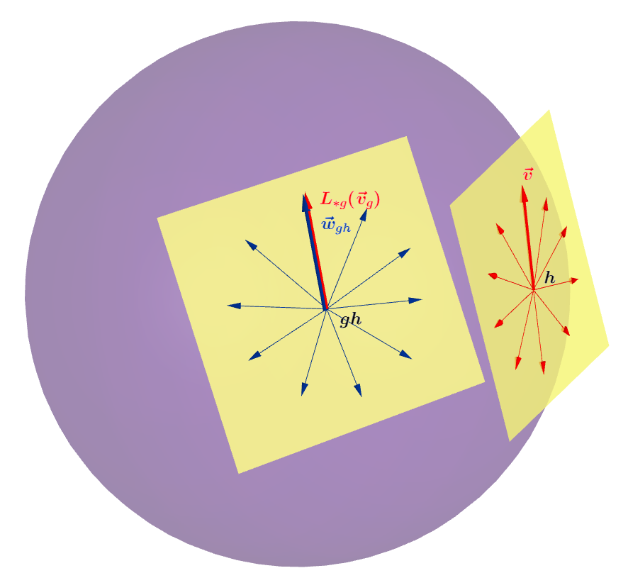

Each vector in the tangent space at the identity generates a left invariant vector field by virtue of the pushforward. The set of these left invariant vector fields is finite dimensional, and isomorphic to the tangent space at the identity, underpinning the exponential map, which allows reconstructing the group from the tangent space at the identity through the exponential map, as in this simple example of the circle, which also illustrates a left invariant vector field on the manifold (the circle $S^1$):

Example: The [circle group](https://en.wikipedia.org/wiki/Circle_group):

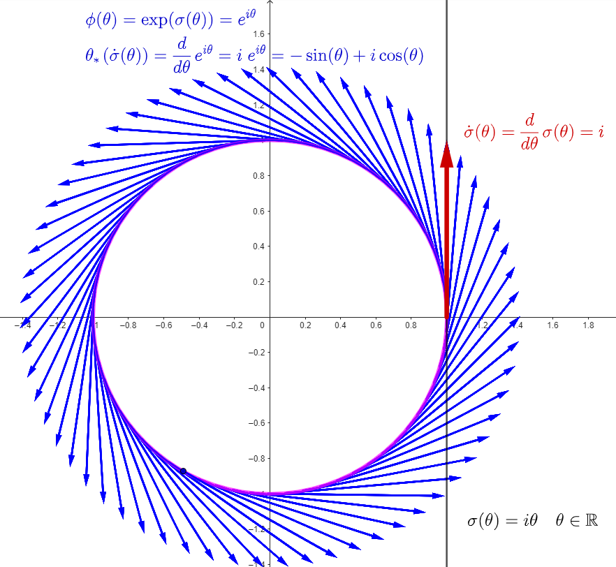

The vector field (blue arrows at each point) is generated by the pushforward of the tangent vector at the identity $1$ or $1 + oi.$ The group is parameterized by the line

along the imaginary axis (see here). The points in this vertical line along the imaginary axis are mapped to the circle by $\phi(\theta)=e^{i\theta}.$ The tangent vector to this parameterized line at $\theta=0$ is

$$X_{\theta=0}=\frac d{d\theta}(\theta)=
1\hat i=\partial_\theta.$$

An entire vector field can be generated by pushing forward the vectors tangent to the point $\theta=0$ along the imaginary line, resulting from the group operation of addition on the group $(i\mathbb R, +)$ on this $1i$ element at the identity as follows

$$Y_{\phi(p)}=\phi_*(X_p)=\left( 1\,
\partial _\theta\right)\, \left( e^{i\theta}\right)=-\sin\theta +i\cos
\theta=\color{blue}{i e^{i\theta}}.$$

Contrarily, the $S^1$ manifold (the circle) can be realized as the [integral curve](https://en.wikipedia.org/wiki/Integral_curve#:~:text=Integral%20curves%20are%20known%20by,fluid%20are%20known%20as%20streamlines.) of this vector field.

##### Why is this a left-invariant vector field?

Let’s first just contruct the vector fiel as in the image: At each point on the circle there is a vector pointing counter-clockwise, tangent to the circle, and of unit length.

Now we have a function that maps from one point in the manifold to another - in [this post](https://math.stackexchange.com/a/1725873/152225) it is the function $F,$ which in the way this example is set up would be $\phi(\theta).$ Now suppose we left-multiply a point on the circle given by $\phi(\pi/4) =e^{i\pi/4}$ by the point $\phi(\pi/2) =e^{i\pi/2}.$ This will land us at $e^{i\pi/4}\,e^{i\pi/2}=e^{i\pi3/4}.$ Applying the pushforward would result in:

$$\left(i\, e^{i\pi/4}\right)
\,e^{i\pi/2}=i\, e^{i\pi3/4}=
-\sin\frac{3\pi}{4}+i\,\cos\frac{3\pi}{4}=-0.7-0.7i$$
which is exactly the vector at $135^\circ$.

From [page 58 of An Introduction to Differential Geometry through Computation by Mark E. Fels](https://digitalcommons.usu.edu/cgi/viewcontent.cgi?article=1000&context=oer_textbooks):

Let $\phi: \mathbb R^n \to \mathbb R^m$ be a $C^\infty$ function and let $p \in \mathbb R^n$. The function $\phi$ can be used to define a map

$$\phi_{∗,p} : T_p \mathbb R^n \to
T_{\phi(p)}\mathbb R^m$$

The map is $\phi_{*,p}$ called **the pushforward**, the differential, or the Jacobian of $\phi$ at the point $p.$

The **pushforward** of the tangent vector to a curve $\sigma$ at $p = \sigma(t_0)$ is the tangent vector of the image curve $\phi(\sigma)$ at $q = \phi(\sigma(t_0)).$ That is,

$$\phi_{∗,p}\;\dot\sigma(t_0) =
\phi_{∗,p}\;X_p =\left. \left ( \frac{d}{dt}\, \phi \; \circ \; \sigma
\right) \right|_{t=t_0}$$

For the tangent vector $X_p = \dot \sigma (t_0)$ where $p = \sigma(t_0).$ In coordinates:

$$X_p = \sum_{i=1}^n \left.
\frac{d\,\sigma^i}{dt} \right|_{t=t_0} \left. \frac{\partial}{\partial
x^i}\right|_p$$

For the curve $\phi(\sigma(t)),$ let $Y_q$ be the tangent vector at $q = \phi(\sigma(t_0))$ which is

$$\begin{align}
Y_q &= \sum_{i=1}^n \left.
\frac{d\,\phi^i\left(\sigma(t)\right)}{dt} \right|_{t=t_0} \left.
\frac{\partial}{\partial y^i}\right|_q \\[3ex]
&= \sum_{i=1}^n \; \left( \sum_{j=1}^n \left.
\frac{\partial\,\phi^i}{\partial x^j} \right|_p \left.
\frac{d\sigma^j}{dt}\right|_{t=t_0} \right) \left.
\frac{\partial}{\partial y^i}\right|_q
\end{align}$$

where $(y^i)_{1≤i≤n}$ denotes the coordinates on the image space of $\phi.$

#### On the derivation notation of a vector field:

A vector field can be expressed as a derivation or expressed in coordinates.

$$X_{(x,y)}=y \, \frac \partial {\partial
x} - x \, \frac \partial {\partial y}$$

or as an element of $\mathbb R^2$ as

$$X_{(x,y)}=(y, -x)$$

corresponding to the coefficients.

#### On tangent vectors interpreted as derivatives - intuition:

From [here, page 53 for examples](https://github.com/RInterested/statistics/blob/gh-pages/Vector%20fields%20acting%20on%20functions%20Arthur%20J.%20Parzygnat%20page%2050.pdf) and [here](https://youtu.be/tmPZoGBeDvs), the differential at a point $x$ of an open set $\mathcal U \subseteq \mathbb R^m$ of a differentiable function $f: \mathbb R^m \to \mathbb R^n$ belongs to a set of linear transformations or linear homomorphism $\text{Hom}(\mathbb R^m , \mathbb R^n).$ This is denoted as $D_xf,$ and it is the first order linear approximation to the differentiable function $f$ at $x.$

If $f: \mathbb R^m \to \mathbb R$ is a differentiable function and $V: \mathbb R^m \to \mathbb R^m$ is a vector field $Vf: \mathbb R^m \to \mathbb R$ is a function defined in $x \in \mathbb R^m$ as

$$x \mapsto (Vf)(x):=
\underset{\text{differential of }f\text{ at } x\quad}{(D_xf)}
\underset{\text{applied to the vector }V \text{ at
}x}{(V(x))}$$

hence $(f\circ v)'(x)$ which would imply the chain rule.

##### Examples:

If a vector field $W: \mathbb R^2 \to \mathbb R^2$ is defined as

$$(x,y) \mapsto W(x,y) := (-x,y)$$
and the function $f: \mathbb R^2 \to \mathbb R$ is

$$(x,y) \mapsto f(x,y):= x^2 -
y^2$$

Calculate $(Wf)(x,y) = (D_{(x,y)}f)(W(x,y))$ for all $(x,y) \in \mathbb R^2.$

$$\begin{align}
(Vf)(x,y) &= (D_{(x,y)}f)(V(x,y))\\[2ex] &=
\begin{bmatrix}\frac\partial{\partial x}(x^2-y^2)&
\frac\partial{\partial y}(x^2-y^2)\end{bmatrix}\begin{bmatrix}-x\\
y\end{bmatrix}\\
&=\begin{bmatrix}2x&
-2y\end{bmatrix}\begin{bmatrix}-x\\
y\end{bmatrix}\\
&=-2(x^2+y^2)
\end{align}$$

If, instead we have the same function $x^2 -y^2$, but the vector field $V(x,y):=(y,-x),$ the result will be

$$\begin{align}
(Vf)(x,y) &= (D_{(x,y)}f)(V(x,y))\\[2ex]
&=\underset{\text{Jacobian matrix}}{
\begin{bmatrix}\frac\partial{\partial x}(x^2-y^2)&
\frac\partial{\partial y}(x^2-y^2)\end{bmatrix}}\begin{bmatrix}y\\
-x\end{bmatrix}\\[3ex]
&=\begin{bmatrix}2x&
-2y\end{bmatrix}\begin{bmatrix}y\\
-x\end{bmatrix}\\
&=4xy
\end{align}$$

Tangent vectors on a manifold are (directional) derivative operators on arbitrary smooth functions at a point $p$ along a curve $\gamma: \mathbb R \to \mathcal M$ (as explained [here](https://youtu.be/UPGoXBfm6Js?t=266)). They are linear maps $X_{\gamma,p}: \mathcal C^\infty(\mathcal M) \to \mathbb R,$ sending an arbitrary function $f$ to

$$f \mapsto (f \circ
\gamma)'(0)$$

expressed as the tangent vector to the curve $\gamma$ at the point $p\in \mathcal M.$

The idea of acting on a smooth arbitrary function on the manifold is as independent of the function selected as a function like $f(x) = x^2$ is independently well defined regardless of what $x$ is entered.

The function $f$ would be the analogue of the scalar function and the directional derivative operator (the tangent vector in differential geometry) would combine the directional vector of mulivariable calculus and the $\nabla$ or gradient into one single operator.

#### On the pushforward:

The push forward $\varphi_*$ of a map $\varphi: \mathcal M \to \mathcal N$ is defined [here](https://youtu.be/XZcKSoI17r0?t=1830) as a linear map $\varphi_*: T_p\mathcal M \to T_{\varphi(p)}\mathcal N$ defined for $x\in T_p\mathcal M$

$$\varphi_*(x)f := x(f \circ \varphi)$$

with $f$ a smooth function in $\mathcal N$ to the reals.

Therefore, when contemplating a smooth map $\varphi$ from a manifold $\mathcal M$ to a second manifold $\mathcal N,$ the directional derivative at the point on $\mathcal N$ that $p$ is sent (i.e. the pushed forward vector) should be informed by the original tangent vector in $\mathcal M,$ which is again a derivative on an arbitrary function on $\mathcal M,$ as well as the measurement of the changes in the function $\varphi$ itself (in a chart, the changes in the coordintes applied to $\mathcal N$ caused by changes in the coordinates in a chart in $\mathcal M.$ This is nothing other that the chain rule.

The notes from [here](https://youtu.be/11f7hiT3iG0) are illustrative.

> Let $F(x^1, x^2) = (x^1 + x^2, x^1 - x^2)$. Consider a parametrized curve $\alpha(t) = (a(t),b(t)).$ The image of $\alpha$ under $F$ is:

> $$(F \circ \alpha)(t) = F(a(t),b(t)) =
> (a(t) + b(t), a(t) - b(t))$$

> The velocity vector for $\alpha$ is $\alpha'(t) = \langle a'(t), b'(t)\rangle$

> $$(F\circ \alpha)'(t) = \langle
> a'(t) + b'(t), a'(t) - b'(t) \rangle =
> \begin{bmatrix}1&1\\1&-1\end{bmatrix} \begin{bmatrix}a'(t)
> \\ b'(t)\end{bmatrix}$$

> of course, the matrix above is just the Jacobian matrix of $F$. In particular, we see a tangent vector $\langle 1,0 \rangle$ would be moved to $\langle 1,1 \rangle$ and the tangent vector $\langle 0,1\rangle$ is transported to $\langle 1, -1 \rangle.$ The columns of the Jacobian matrix tell us how the basis tangent vectors are transformed. Here we took for granted the existence of a Cartesian coordinate system in the range. To allow for different dimensions, we ought to make our observation in a more generalizable fashion. I’ll use $e_1, e_2$ for the domain and $f_1, f_2$ for the range:

> $$e_1 \mapsto f_1 + f_2 ,\quad e_2
> \mapsto f_1- f_2$$

> Now in the derivation notation for tangent vectors, $e_1 =\frac \partial {\partial x^1}$ and $e_2 = \frac \partial {\partial x^2},$ and for Cartesian coordinates $(y^1,y^2)$ for the range $f_1 =\frac \partial{\partial y^1},\; f_2 =\frac \partial {\partial y^2}.$ We have

> $$\frac\partial{\partial x^1}\mapsto
> \frac\partial{\partial y^1}+\frac\partial{\partial y^2},\quad
> \frac\partial{\partial x^2}\mapsto \frac\partial{\partial
> y^1}-\frac\partial{\partial y^2}$$

> Another example $(**)$, $F(x^1,x^2)=(e^{x^1 + x^2}, \sin x^2, \cos x^2).$ Once more, consider the curve $\alpha= (a,b).$ Hence $\alpha'=\langle a',b'\rangle$ and

> $$(F\circ \alpha)'=\langle
> e^{a+b}(a'+b'), (\cos b)b', (-\sin b)b'
> \rangle$$

> We find the tangent $\langle a', b'\rangle =\langle 1,0 \rangle$ maps to $\langle e^{a+b},0,0\rangle,$ whereas the tangent $\langle a', b'\rangle =\langle 0,1 \rangle$ maps to $\langle e^{a+b},\cos b,-\sin b\rangle$ with respect to the point $\alpha =(a,b)$ of the curve. The Jacobian of $F$ at $(a,b)$ is

> $$\begin{bmatrix}e^{a+b}& e^{a+b}\\0
> & \cos b \\ 0 & -\sin b\end{bmatrix}$$

> Following the notation of the last example, but now with $(y^1, y^2,y^3)$ coordinates for the image,

> $$\frac\partial{\partial x^1}\mapsto
> e^{a+b}\frac\partial{\partial y^1}\quad \frac\partial{\partial
> x^2}\mapsto e^{a+b}\frac\partial{\partial y^1}+\cos b
> \frac\partial{\partial y^2}-\sin b\frac\partial{\partial y^3}$$

> Notice $y^j\circ F = F^j$ is immediate from the definition of Cartesian coordinates and component functions. What we really have above is

> $$\frac\partial{\partial x^1}\mapsto
> \sum_{j=1}^3 \frac{\partial(y^j\circ F)}{\partial
> x^1}\frac\partial{\partial y^j}$$

> and

> $$\frac\partial{\partial x^2}\mapsto
> \sum_{j=1}^3 \frac{\partial(y^j\circ F)}{\partial
> x^2}\frac\partial{\partial y^j}$$

$(**)$ From this example a more structured intuition of the definition of the tangent vector as a linear map $X_{\gamma, p}$ from differentiable $\mathcal C^\infty (\mathcal M)$ function on the manifold to $\mathbb R$ may be possible. Here is a reformulation with a slightly different set up. The key observation is that $X_{\gamma,p}$ does not depend on the function $f$ on the manifold. This is intended to give an example of the tangent vector at a point $p$ along a smooth curve $\gamma(t)$ on a manifold as a linear map (directional derivative) from a smooth function $f$ to the real numbers constructed as

$$f \mapsto (f \circ
\gamma)'(0)$$

and where $p =\gamma(0).$

The attempt at illustrating this construct imagines the function $f(x,y)= e^{-\left((x+ 2.13)^2+(y+1.16)^{2}\right)}$ (a bivariate Gaussian bell curve) representing the density of historically relevant buildings and monuments at any given point in the city of Paris (from [this site](https://parismap360.com/paris-tourist-map)):

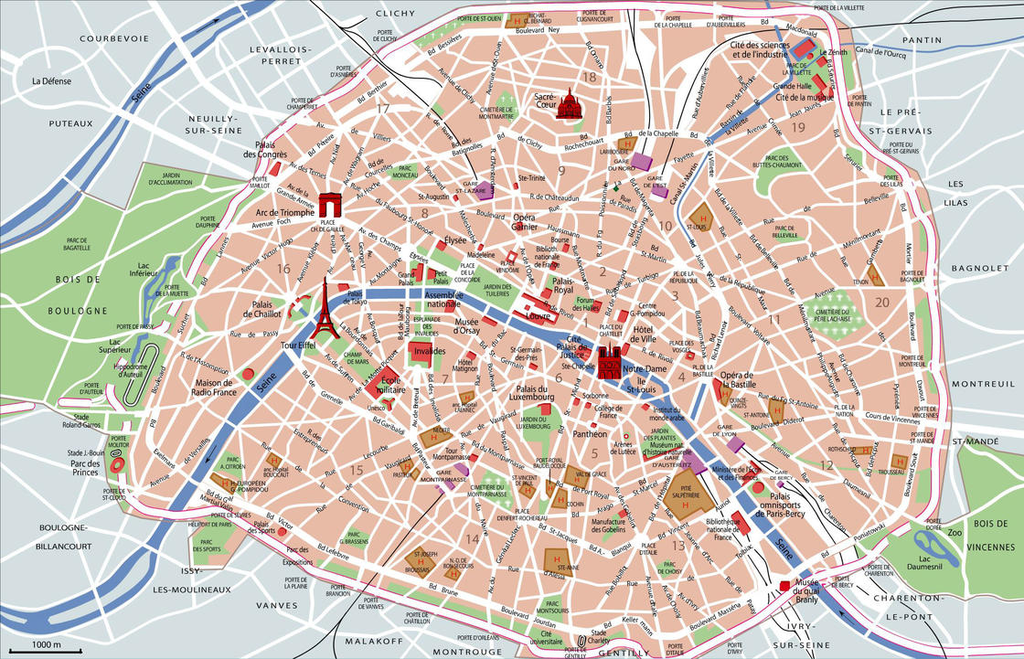

The chart used that allows Cartesian coordinates imposed on the manifold is centered at the Louvre $(0,0),$ and the function $f$ happens to have its maximum around des Champs-Élysées, so that we expect the density of historical buildings to start decreasing away from that point.

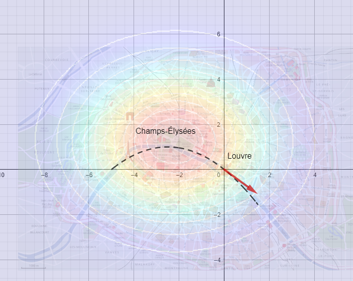

This function is evaluated along a curve $\gamma(t)= -0.16(t +2.5)^2 +1$ which when mapped onto the chart is $\gamma(t)=(t, -0.16(t +2.5)^2 +1).$ It roughly follows the Seine river in the center of Paris. The Louvre is the point $p=\gamma(0)=(0,0).$ The velocity vector or tangent at a point is $\begin{bmatrix}1 & -0.32(t+2.5)\end{bmatrix}^\top,$ or in the chart, $\begin{bmatrix}1 & -0.32(x+2.5)\end{bmatrix}^\top.$

For the attempted calculations the composition $f\circ \gamma$ is expressed as $f(a(t), b(t)).$

$$\begin{align}
\small X_pf &= (f\circ \gamma)'(t=0) \\[2ex]
&=\left.\left[ \frac{\partial f}{\partial x} \left(x(t),y(t)\right)
\,
\color{red}{x'(t)}+ \frac{\partial f}{\partial
y}\left(x(t),y(t)\right)\,\color{red}{y'(t)}\right]\right|_{t=0}
\\[3ex]
&= \begin{bmatrix}\frac{\partial f}{\partial x} (p) &
\frac{\partial f}{\partial y}(p)\end{bmatrix}^\top
\color{red}{\underset{\text{tangent vector
}\\\text{(velocity)}}{\begin{bmatrix}x'(0)\\y'(0)\end{bmatrix}}} \\[3ex]
& = \left. \begin{bmatrix}-2 (x + 2.13) e^{(-(x + 2.13)^2 - (y +
1.16)^2)} \\ -2 (y + 1.16) e^{(-(x + 2.13)^2 - (y +
1.16)^2)}\end{bmatrix}^\top\right|_{p=\gamma(0)}\small\color{red}{\begin{bmatrix}x'(0)
\\ y'(0)\end{bmatrix}} \\[3ex]
&=\small{ 2 (t + 2.13) e^{-(t + 2.13)^2 - ((-0.16 (t + 2.5)^2 + 1) +
1.16)^2} \\ + (-2 ((-0.16 (t + 2.5)^2 + 1) + 1.16) e^{-(t + 2.13)^2 -
((-0.16 (t + 2.5)^2 + 1) + 1.16)^2)}(-0.32 (t + 2.5))
\Big|_{t=0}}\\[2ex]
&=-0.00670189
\end{align}$$

However, these can be made more efficient as [illustrated by Professor Shifrin](https://math.stackexchange.com/a/4586645/994433):

> The chain rule says that
> $$(f\circ\gamma)'(0) =
> Df(\gamma(0))\gamma'(0) = Df(p)\gamma'(0).$$
> We have $p=(0,0)$ and $\gamma'(0)=\begin{bmatrix} 1\\ -.32(2.5)\end{bmatrix} = \begin{bmatrix} 1\\ -0.8\end{bmatrix}$. We also have, according to your formulas, $Df(p) = Df(0,0) \approx \begin{bmatrix} -0.01188 & -0.00647\end{bmatrix}$. Thus,
> $$Df(p)\gamma'(0) \approx \begin{bmatrix}
> -0.01188 & -0.00647\end{bmatrix}\begin{bmatrix} 1\\-0.8\end{bmatrix}
> \approx -0.01188 + 0.00647\cdot 0.8 \approx -0.0067.$$

Observe that this can also be understood of the [**tangent map**](https://mathworld.wolfram.com/TangentMap.html), which is a map between tangent bundles of $\mathcal M$ and $\mathcal N.$ Again there is a curve $\gamma$ passing through the point $p$ at time $0$ with velocity $\gamma'(0),$ and the tangent map is defined as

$$T\phi(\gamma'(0))=(\varphi \circ
\gamma)(0)$$

A great numerical example is found in [this question and answer](https://math.stackexchange.com/a/1097316/152225) (below) with one important caveat: this example is of a vector field $X$:

> Let $(s,t)$ be coordinates on $\mathbb{R}^2$ and $(x,y,z)$ be coordinates on $\mathbb{R}^3$. Let $g:\mathbb{R}^2\to\mathbb{R}^3$ be defined by $g(s,t)=(\sin(t),st^2,s^3-1)$.

> Let $X_p\in T_p\mathbb{R}^2$ be given by $X_p=\frac{\partial}{\partial s}|_p - \frac{\partial}{\partial t}|_p$, compute the push-forward $g_*X_p$.

> Let $\omega$ be the smooth $1$-form $\omega=dx+xdy+y^2dz$; find the pullback $g^*\omega$.

Answer:

> Let’s work out some computations: first, the push-forward of the vector field $X = \frac{\partial }{\partial s} - \frac{\partial }{\partial t}$, denoted $g_* X$. To do so, we need to find the push forward of the two vector fields $\frac{\partial}{\partial s}$ and $\frac{\partial}{\partial t}$. This is given by
> $$g_* \left( \frac{\partial}{\partial s} \right)
> = \frac{\partial x}{\partial s} \frac{\partial}{\partial x} +
> \frac{\partial y}{\partial s} \frac{\partial}{\partial y} +
> \frac{\partial z}{\partial s}\frac{\partial }{\partial z} = t^2
> \frac{\partial}{\partial y} + 3s^2 \frac{\partial}{\partial z},$$
> and
> $$g_* \left( \frac{\partial}{\partial t} \right)
> = \frac{\partial x}{\partial t} \frac{\partial}{\partial x} +
> \frac{\partial y}{\partial t}\frac{\partial}{\partial y} +
> \frac{\partial z}{\partial t} \frac{\partial}{\partial z} = \cos(t)
> \frac{\partial}{\partial x} + 2st \frac{\partial}{\partial y}.$$
> Then,
> $$g_* X = g_* \left( \frac{\partial}{\partial s} \right) - g_* \left(
> \frac{\partial}{\partial t} \right) = -\cos(t) \frac{\partial}{\partial
> x} + (t^2 -2st) \frac{\partial}{\partial y} + 3s^2
> \frac{\partial}{\partial z}.$$
> A remark: in $g_* X$, I should have written this without reference to $s$ and $t$ (that is, solve the equations $x=\sin(t)$ and $y=st^2$ and $z=s^3-1$ for $s$ and $t$ in terms of $x,y,z$), however it was not clear to me how to do that here.

> If you find that you need practice with computations when dealing with manifolds and differential geometry (e.g. push forwards, pullbacks, Lie derivatives, etc.), I recommend looking at an exercise-heavy book such as Gadea & Masque’s [“Analysis and Algebra on Differentiable Manifolds, A Workbook for Students and Teachers”](http://www.amazon.com/Analysis-Algebra-Differentiable-Manifolds-Workbook/dp/904813563X). I found this one to be very helpful when learning this material for the first time.

#### Example

Let $\phi: \mathbb R^2 \to \mathbb R^3$ (no manifold is more homeomorphic to Euclidean space than that!) is given by

$$\phi(x,y) = \left(u=x^2 + y^2, v= x^2 -
y^2, w =xy \right)$$

and the curve $\sigma: \mathbb R \to \mathbb R^2$:

$$\sigma(t) = (1 + 3t , 2 -
2t)$$

which at $t=0$ corresponds to

$$\sigma(0) = (1,2).$$

The derivative is

$$\dot \sigma(t)=(3,-2)$$

which doesn’t have any dependency on $t,$ and therefore the tangent vector at $t=0$ is directly given by

$$\left(\dot
\sigma(0)\right)_{\sigma(0)}=(3, -2)_{(1,2)}$$

The image curve $\phi \circ \sigma: \mathbb R \to \mathbb R^3:$

$$\phi\left( \sigma(t)\right)= \left(
(1+3t)^2+(2-2t)^2,\quad (1+3t)^2-(2-2t)^2,\quad (1+3t)(2-2t)
\right)$$

and the point mapped from $\sigma(0)=(1,2)$ to $\mathbb R^3$ by $\phi$ is

$$\left. \phi\left(\sigma(t) \right)
\right|_{t=0}=(5,-3,2)$$

The tangent vector to the image curve $\phi\left( \sigma(t)\right)$ is derived as

$$\frac d{dt} \phi\left(
\sigma(t)\right)=\left(26t - 2, \quad 10t +14,\quad -12t
+4 \right)$$

when $t=0$ is

$$\left(\left. \frac{d}{dt} \phi\left(
\sigma(t)\right)\right|_{t=0} \right)_{\phi\left( \sigma(0)\right)} =
(-2, 14, 4)_{(5,-3,2)}$$

The map $\phi_{∗,p}$ has the property that if $(\dot σ(t_0))_{σ(t_0)}$ is the tangent vector to the curve $σ$ at $p = σ(t_0)$ with corresponding derivation $X_p$, then $Y_q = \phi_{∗,p}\,X_p$ is the derivation $Y_q$ corresponding to the tangent vector $\phi \circ \sigma$ at the image point $\phi(p) = \phi(σ(t0)).$ In the example this means $p = (1, 2)$ and $X_p = (3\partial x − 2 \partial y)_{(1,2)}$, and $Y_q = (−2 \partial u + 14 \partial v + 4 \partial w)_{(5,−3,2)} = \theta_{∗,p}X_p$.

Summary:

When $t=0,$ $p=\sigma (0)=(1,2),$ a point in $\mathbb R^2$ which is mapped to $\phi \left( \sigma(0) \right)=(5, -3,2).$

$$\bbox[magenta,15px,border:0.5px solid
black]{\color{white}{\phi_{*,p}=\left.\frac{d}{dt}\phi(\sigma(t))\right|_{t=0}}}$$

The operation whereby the vector $(3,-2)$ is sent to $\mathbb R^3$ is denoted $\phi_{∗,p}\,X_p.$

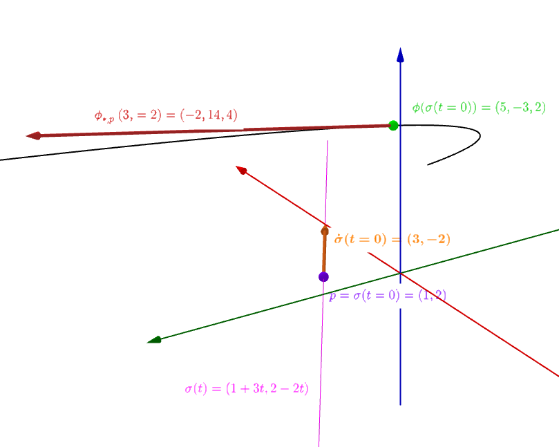

This results can also be obtained as in page 62 of the linked document by considering that the pushed forward of the vector above, defined at $p=\sigma(t=0)=(1,2),$ and labelled $X_p=\dot \sigma(t=0)=(3,-2)$ is $X_p =\left. (3\,\partial_x-2\,\partial_y)\right|_{p},$ and having this vector (remember vector bases in differential geometry are simply differential operators) act on the different coordinates of the map $\phi$ as in:

$$\begin{align}
\phi_{*,p}(X_p)(u) &= \underset{\small\text{derivative
operator}\color{orange}{\Huge
\rightarrow}}{\underbrace{(3\,\partial_x-2\,\partial_y)_{(1,2)}}}\quad\underset{\phi_u}{\underbrace{(x^2+y^2)}}=\left.
3 \partial_x\,(x^2) - 2
\partial_y\,(y^2)=3(2x)-2(2y)\right|_{(1,2)} =6-8=-2\\[2ex]
\phi_{*,p}(X_p)(v) &= \underset{\small\text{derivative
operator}\color{orange}{\Huge
\rightarrow}}{\underbrace{(3\,\partial_x-2\,\partial_y)_{(1,2)}}}\quad\underset{\phi_v}{\underbrace{(x^2-y^2)}}=3\partial_x\,(x^2)-2\partial_y\,(-y^2)=\left.
3(2x) + 2(2y) \right|_{(1,2)} =6+8=14\\[2ex]
\phi_{*,p}(X_p)(w) &= \underset{\small\text{derivative
operator}\color{orange}{\Huge
\rightarrow}}{\underbrace{(3\,\partial_x-2\,\partial_y)_{(1,2)}}}\quad\underset{\phi_w}{\underbrace{(xy)}}=3\partial_x\,(xy)
-2\partial_y\,(xy)=\left. 3(y)-2(x)\right|_{(1,2)}=6-2=4\\[2ex]
\end{align}$$

or

$$\phi_{*,p}(X_p)=(-2\partial_u+
14\partial_v+ 4\partial_w).$$

Or calculating the Jacobian matrix at $(1,2)$

$$\begin{bmatrix}
\frac{\partial\phi^a}{\partial x^i}
\end{bmatrix}_{(1,2)}
=\begin{bmatrix}
2x & 2y\\
2x & -2y\\
y & x
\end{bmatrix}_{(1,2)}=
\begin{bmatrix}
2&4\\2&-4\\2&1
\end{bmatrix}$$

which multiplied times the $X_p=(3,-2),$

$$\begin{bmatrix}
2&4\\2&-4\\2&1
\end{bmatrix}\begin{bmatrix}
3\\-2
\end{bmatrix}=\begin{bmatrix}
-2\\14\\4
\end{bmatrix}$$

This last expression is a clear illustration of the linear transformation from one tangent space to another: the tangent vector $(3,-2)$ at the point $(1,2)$ is sent via matrix multiplication to $(-2, 14,4).$

### The pullback:

From page 115 of the reference above, let’s again begin with a function between two and three dimensional Euclidean space: $\phi: \mathbb R^2 \to \mathbb R^3,$ this time given by

$$\phi(x,y) = \left(u=x + y, v= x^2 - y^2,
w =xy \right)$$
Let a one form at a point $q= \phi(1,2)=(3,-3,2)$ in the target manifold (i.e. $\mathbb R^3$) be $\tau_q$:

$$\tau_q = (2\,du - 3\,dv+
dw)_q$$

The pullback is calculated much like for the calculations of the pushforward above as sending the covector given in $\mathbb R^3$ to $\mathbb R^2$ by applying the exterior derivative to the function $\phi$ componentwise first:

$$\begin{align}
\phi^*_q\; du_q &= \underset{\small\text{d exterior
derivative}}{\underbrace{d(x+y)_{(1,2)}}}=(dx + dy)_{(1,2)}\\[2ex]
\phi^*_q\; dv_q &= \underset{\small\text{d exterior
derivative}}{\underbrace{d(x^2-y^2)_{(1,2)}}}=(2x\,dx
-2y\,dy)_{(1,2)}=(2\,dx - 4\,dy)_{(1,2)}\\[2ex]
\phi^*_q\; dw_q &= \underset{\small\text{d exterior
derivative}}{\underbrace{d(xy)_{(1,2)}}}=(2\,dx + dy)_{(1,2)}\\[2ex]
\end{align}$$

and then feeding the coefficients of the form $\tau_q$:

$$\begin{align}
\left. \phi^*_q\; (2\,du -3 \,dv + dw)
\right|_q&= 2\,\phi^*_q(\left. du \right|_q) -3 \,\phi^*_q(\left.
dv \right|_q) + \phi^*_q(\left. dw \right|_q)\\[2ex]
&= 2(dx+dy) - 3 (2\,dx - 4\,dy) + (2\,dx + dy)\\[2ex]
&= (-2\,dx + 15 \,dy)_{(1,2)}
\end{align}$$

So the differential form $\tau_q$ is specified in $\mathbb R^3,$ which is the *image space* of $\phi$. For every point in the *domain* of $\phi$, i.e. $p \in \mathbb R^2$ we can define the **pullback** as the *differential form* $\alpha_p$ corresponding to the exterior derivative as performed above: componentwise and using the $\phi$ function. This is to say: $\alpha_p = \phi^*_q(\tau_{\phi(p)}).$ The pullback is the map back to $\mathbb R^2$ of the differential form $\tau,$ or $\alpha=\phi^*\tau.$

**Corollary**: we can always pullback a given one-form on the image to another differential one-form on the domain of $\phi.$ However, we cannot create a vector field in $\mathbb R^3$ by pushing forward a vector field in $\mathbb R^2,$ unless the function $\phi$ is a diffeomorphism.

The **pullback** for a one-form in $\mathbb R^3,$ or in general $\mathbb R^m,$ which would have the form $\tau_q \in T^*_q\,\mathbb R^m$ (in the cotangent space), and corresponds to
$$\tau_q = \sum_{a=1}^m \left. c_a\, dy^a
\right|_q$$
with $c_a \in \mathbb R$ being the coefficients, will be given by

$$\bbox[magenta,15px,border:0.5px solid
black]{\color{white}{\phi^*\left( \tau_q\right)=
\phi^* \left(\sum_{a=1}^m \left. c_a\, dy^a \right|_q
\right)=\sum_{a=1}^m c_a\, \left( d\phi^a\right)_p = \sum_{i=1}^n\left(
\sum_{a=1}^m c_a \left. \frac{\partial \phi^a}{\partial x^i}\right|_p
\right)\left. dx^i\right|p\quad}}$$

[Home Page](http://rinterested.github.io/statistics/index.html)

**NOTE: These are tentative notes on different topics for personal use - expect mistakes and misunderstandings.**